# Alpha Hunter 주간 종합 히든젬 보고서

Week 19 — 한국 휴젤(Hugel) · 미국 AppFolio(APPF) · 중국 SIMO(Silicon Motion)

Author

Alpha Hunter × Chimera AI

Published

May 9, 2026

# 주간 종합 요약

**Week 19 (2026-05-05 ~ 2026-05-09) 히든젬 종합 결과**

- **한국 시장**: 휴젤(Hugel, 145020) — 글로벌 보톡스 3강, Q1 사상 최대 실적 달성
- **미국 시장**: AppFolio(APPF) — 부동산 관리 SaaS 독점, AI Realm-X 제2성장
- **중국 시장**: Silicon Motion(SIMO) — NAND 컨트롤러 글로벌 1위, 매출 +105% 폭증

**면책 문구**

이 프로젝트는 가상 투자 시뮬레이션 목적으로 작성되었습니다. 실제 투자 권유가 아닙니다.

# 1 포트폴리오 성과 업데이트

## 1.1 현재 포지션 현황

[figure not shown]

**AROC (Archrock)**: $35.70 → $36.96 (**+3.5%**). Q1 EBITDA $221M (+12% YoY), 가동률 95%, 조정 매출총이익률 72%. 2026 EBITDA 가이던스 $865~$915M 재확인. EPS $0.42 (예상 $0.47 소폭 미스)로 주가 소폭 조정.

**포트폴리오 총 수익**: AROC $51,744 + HPSP ₩53,900,000 + Hugel ₩58,300,000 = **약 $128,460** (투자원금 $123,337 대비 **+4.2%**)

**현금**: $14,020 (총 포트폴리오 대비 약 10%)

## 1.2 포트폴리오 주가 추이

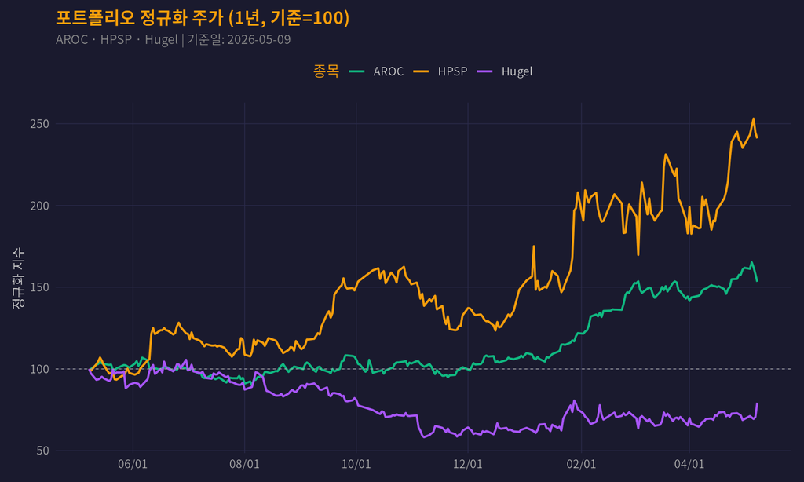

## 1.3 워치리스트 성과 추적

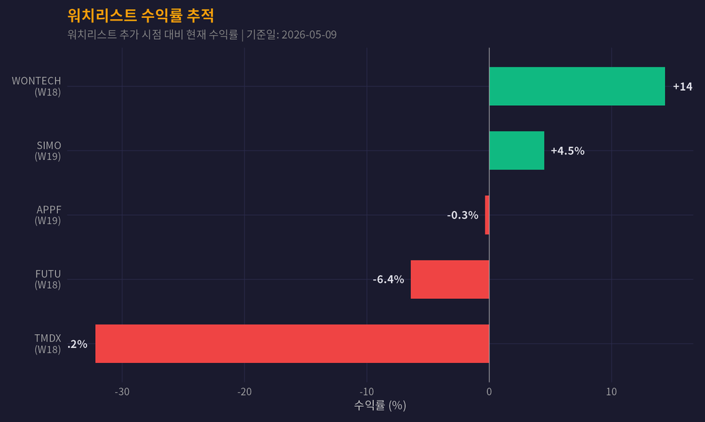

**TMDX 워치리스트 경고**

TransMedics(TMDX)는 5/5 Q1 실적 발표 후 **-32.2% 급락**. EPS $0.20 (예상 $0.63 대폭 미스), 영업이익 -51.6% YoY. 원가 +31.6%, 판관비 +42.1% 급증으로 마진 압력 심각. 2026 가이던스($727-757M)는 유지했으나 신뢰도 훼손. **워치리스트에서 제거** 권고.

**WONTECH 워치리스트 호조**

원텍(336570)은 W18 추가 이후 **+14.3%** 상승 (₩7,320 → ₩8,370). K-뷰티 의료기기 성장 모멘텀 지속. 목표가 ₩9,500 접근 중.

# 2 한국 히든젬: 휴젤 (Hugel, 145020)

## 2.2 투자 논거

**Q1 2026 사상 최대 실적 달성:**

1. **매출 1,166억원** (+29.9% YoY): 해외 보톡스+필러 매출 708억원 (+46% YoY)
2. **영업이익 476억원** (+22.3%): 미국 직판 비용 선반영에도 견조한 이익 성장
3. **순이익 406억원** (+31.5%): 순이익률 34.8%의 고수익 기업
4. **FDA+NMPA+CE 동시 허가**: 한국 유일 3대 시장 진입 기업
5. **미국 직판 2026H2 본격화**: 마진 구조 개선의 게임체인저

## 2.3 주가 추이 (52주)

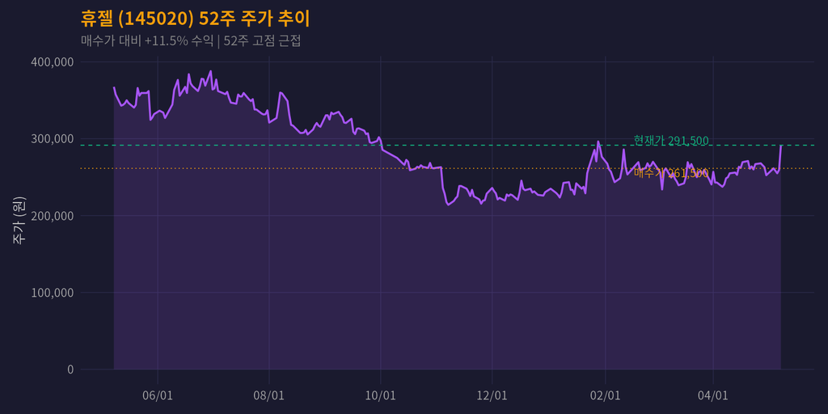

## 2.4 실적 추이 (매출/영업이익)

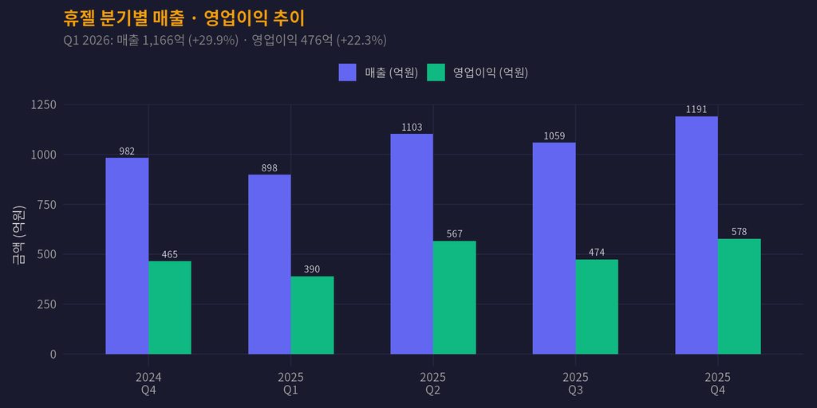

## 2.5 밸류에이션 비교 (동종업종)

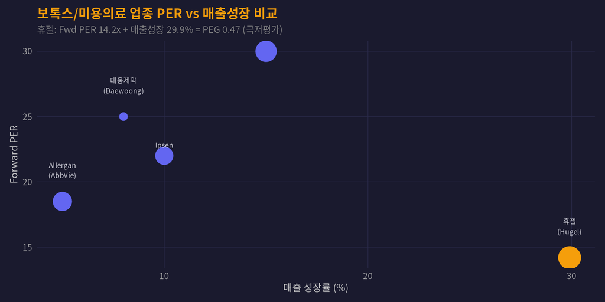

## 2.6 워런 버핏 해자(Moat) 레이더

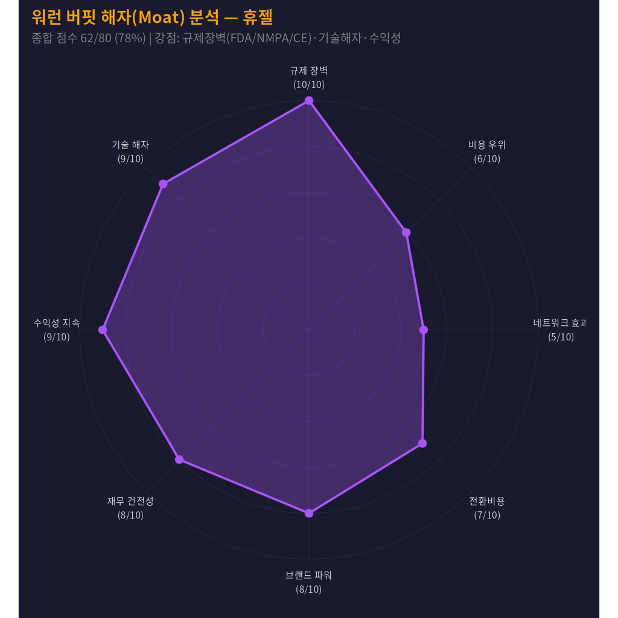

**버핏 렌즈 해석**: 휴젤은 FDA+NMPA+CE 3대 시장 동시 허가라는 **한국 유일의 규제 해자**(10/10)를 보유. 보톡스의 반복 시술 특성으로 전환비용(7/10)이 높고, 영업이익률 40%+의 지속적 수익성(9/10) 입증. 네트워크 효과가 제한적인 점이 감점 요인이나, 미국 직판 전환이 브랜드 파워를 더 강화할 전망.

## 2.7 피터 린치 스토리 점수

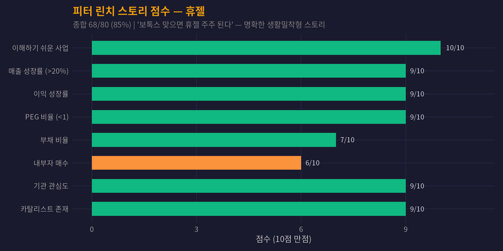

## 2.8 리스크 팩터

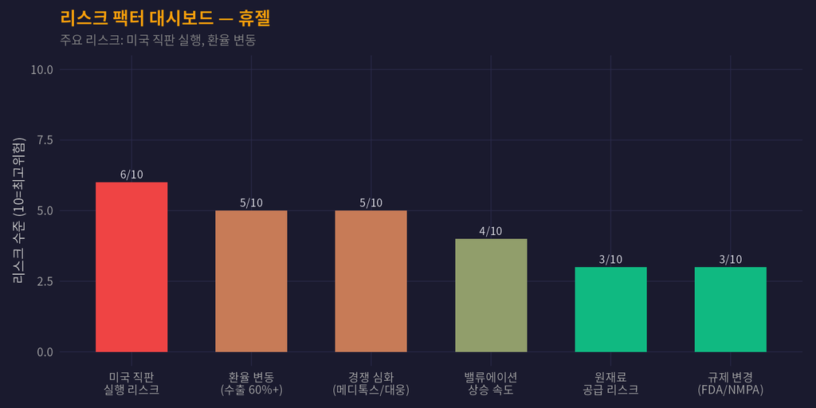

## 2.9 매수/목표/손절 시나리오

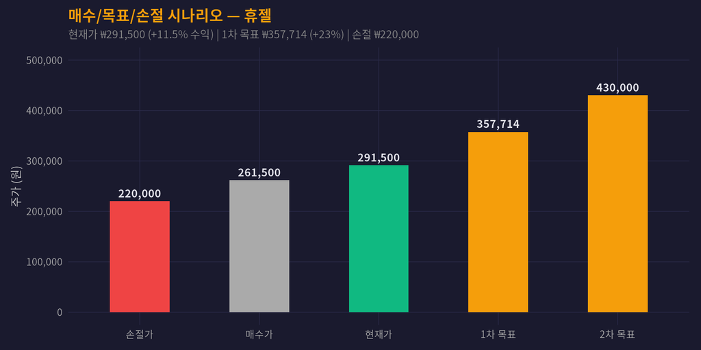

# 3 미국 히든젬: AppFolio (APPF)

## 3.1 기업 개요

- **종목명**: AppFolio, Inc. (APPF, NASDAQ)
- **업종**: Technology / Property Management SaaS
- **시총**: $5.9B
- **현재가**: $166.59
- **52주 범위**: $137 ~ $325
- **매출 성장**: +20.4% YoY
- **영업이익률**: 19.4%
- **매출총이익률**: 63.7%
- **Forward PER**: 20.3x
- **ROE**: 32.6%
- **애널리스트 컨센서스**: **Strong Buy** (9명)

## 3.2 투자 논거

1. **부동산 관리 SaaS 독점**: 950만 유닛(아파트/상가) 관리 — 미국 1위 플랫폼
2. **AI Realm-X 혁명**: AI 사용량 7x 증가, 임대·유지보수·회계 자동화
3. **52주 고점 대비 -49%**: 과매도 구간, 2026 가이던스 $1.1B+ 상향
4. **자사주매입 $125M**: 경영진이 밸류에이션 매력 직접 증명
5. **고수익 SaaS 모델**: 매출총이익률 63.7%, 영업이익률 19.4%, ROE 32.6%

## 3.3 워런 버핏 해자(Moat) 레이더

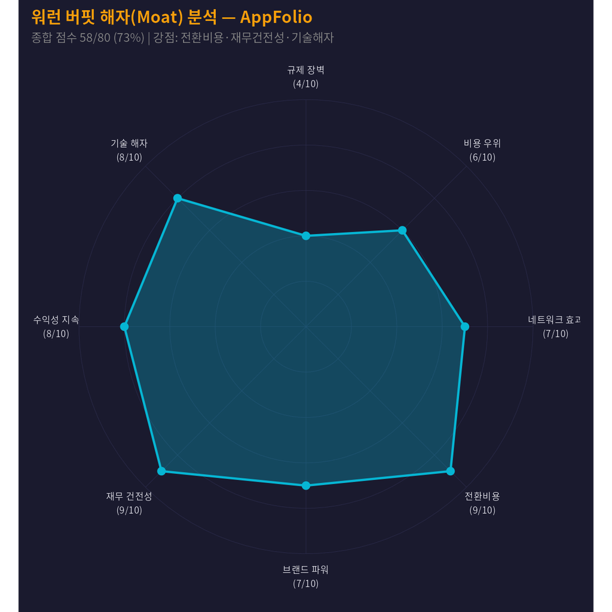

**버핏 렌즈 해석**: AppFolio는 부동산 관리 소프트웨어의 **높은 전환비용**(9/10)이 핵심 해자. 950만 유닛 데이터가 축적되면 경쟁사 이동이 극도로 어렵습니다. 무부채 재무구조(9/10)와 AI Realm-X 기술 해자(8/10)도 강력. 규제 장벽이 낮은 점(4/10)이 유일한 약점.

## 3.4 피터 린치 스토리 점수

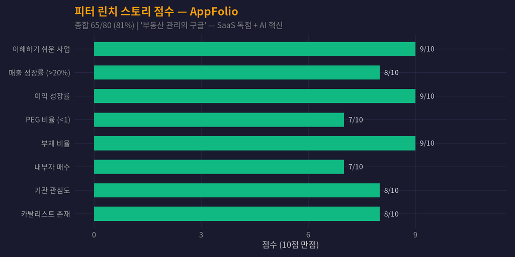

# 4 중국 히든젬: Silicon Motion (SIMO)

## 4.1 기업 개요

- **종목명**: Silicon Motion Technology (SIMO, NASDAQ)
- **업종**: Semiconductors / NAND Flash Controller
- **시총**: $8.6B
- **현재가**: $253.59 (워치리스트 추가 후 +4.5%)
- **매출 성장**: +105.5% YoY (Q1 2026)
- **영업이익률**: 18.2% (비GAAP)
- **매출총이익률**: 47.2%
- **Forward PER**: 25.1x
- **PEG**: 0.70
- **애널리스트 컨센서스**: **Strong Buy** (10명)

## 4.2 투자 논거

1. **NAND 컨트롤러 글로벌 1위**: Samsung/SK Hynix/Kioxia 3대 NAND 메이커에 동시 공급
2. **Q1 매출 $342M (+105% YoY)**: 역대 최대 분기 매출 달성
3. **MonTitan AI SSD**: NVIDIA AI 생태계 진입, 데이터센터용 고성능 SSD 컨트롤러
4. **PEG 0.70, 무차입**: 성장 대비 합리적 밸류에이션, 순현금 상태
5. **Q2 가이던스 $393-411M**: 전분기 대비 +15~20% 추가 성장 예고

## 4.3 워런 버핏 해자(Moat) 레이더

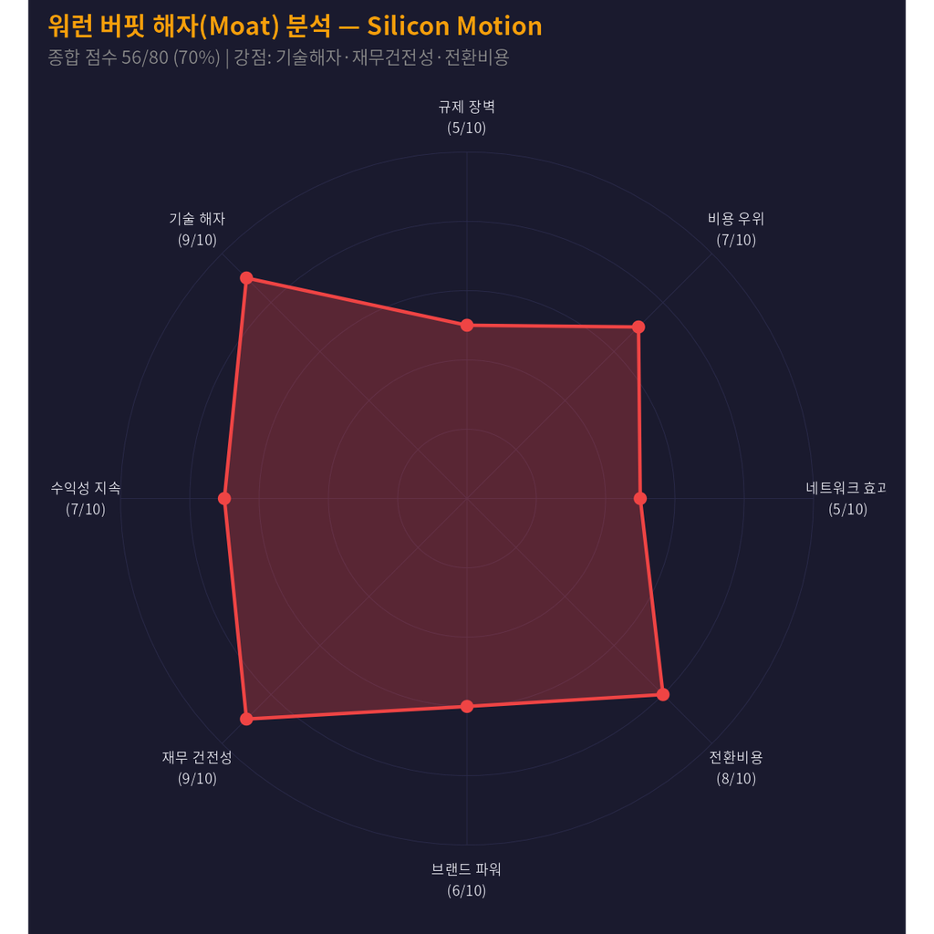

## 4.4 피터 린치 스토리 점수

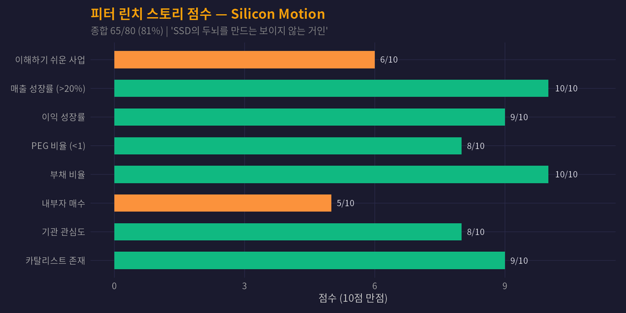

# 5 종합 판정

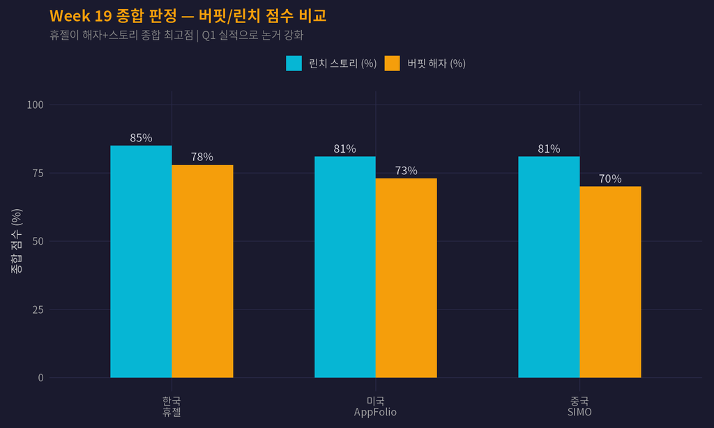

## 5.1 Week 19 결론

**한국 휴젤(145020)** — **포트폴리오 유지, 목표가 상향 검토**

**미국 AppFolio(APPF)** — **워치리스트 유지**

- 52주 고점 -49% 과매도 구간, SaaS 독점 + AI 혁신 스토리 유효
- $166.59 현재가에서 타겟 $228(+37% 업사이드)
- 다음 실적 확인 후 포트폴리오 편입 검토

**중국 SIMO** — **워치리스트 유지**

- Q1 매출 +105% 폭발적 성장, MonTitan AI SSD 카탈리스트
- $253.59 현재가에서 Base $260(+3%), Bull $290(+14%)
- 52주 고점 근접 부담 → 눌림목 시 매수 검토

**TMDX 교훈**: Q1 실적 대참사(-32.2%)로 워치리스트 제거 권고. “독점 기술 ≠ 실적 보장” — 원가 관리 실패가 해자를 무력화할 수 있음을 재확인.

**면책 문구**

이 프로젝트는 가상 투자 시뮬레이션 목적으로 작성되었습니다. 실제 투자 권유가 아닙니다. 모든 데이터는 yfinance 및 공개 웹소스에서 수집되었으며, 정확성을 보증하지 않습니다.

*Alpha Hunter × Chimera AI | Week 19 종합 보고서 | 2026-05-09*